# QNR Simulation - WNTR-Quantum

- QNR Simulation
  - Set up water network model
  - Solve model classically using EpanetSimulator
  - Solve model using the classical Cholesky solver from QuantumEpanetSimulator
  - Check that the classical results are equivalent
  - Solve water network with QuantumEpanetSimulator and VQLS

# QNR Simulation

We illustrate here how to use the Variational Quantum Linear Solver as part of the Newton Raphson to simulate the water pressure and flow of a small water network using wntr-quantum.

## Set up water network model

In this example, we test our quantum solvers into a slightly larger network as contained in `Net2Loops.inp`. Let's start by setting up the model:

```python
import os
from pathlib import Path
import wntr
import wntr_quantum

# Define the directory path
epanet_tmp_dir = Path("/Users/murilo/scratch_dir/.epanet_quantum")

# check if the directory exists
if not epanet_tmp_dir.exists():
    epanet_tmp_dir.mkdir(parents=True, exist_ok=True)

# set the environment variables
os.environ["EPANET_TMP"] = str(epanet_tmp_dir)
os.environ["EPANET_QUANTUM"] = "/Users/murilo/Documents/NLeSC_Projects/Vitens/EPANET"

# set up network model
inp_file = "networks/Net2Loops_modified.inp"  # reproduces the values in https://doi.org/10.3390/w14060851
wn = wntr.network.WaterNetworkModel(inp_file)

# plot network
wntr.graphics.plot_network(wn, title=wn.name, node_labels=True)

# explicitly set Hazen-Williams head loss formulas and pressure dependent demand mode
wn.options.hydraulic.headloss = "H-W"  # 'D-W'
wn.options.hydraulic.demand_model = "PDD"  # 'PDD'

# required pressure: the pressure above which the consumer should receive the desired demand
wn.options.hydraulic.required_pressure = 30.0  # m
# minimum pressure: this is the pressure below which the consumer cannot receive any water
wn.options.hydraulic.minimum_pressure = 0.0  # m

# set time duration of the simulation (in seconds)
wn.options.time.duration = 0

# print options
dict(wn.options.hydraulic)
dict(wn.options.time)
```

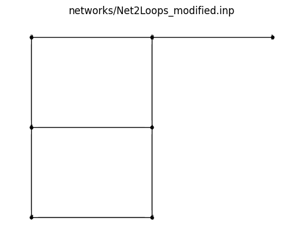

```
{'duration': 0.0,
 'hydraulic_timestep': 3600,
 'quality_timestep': 300,
 'rule_timestep': 360,
 'pattern_timestep': 7200,
 'pattern_start': 0.0,
 'report_timestep': 3600,
 'report_start': 0.0,
 'start_clocktime': 0.0,
 'statistic': 'NONE',
 'pattern_interpolation': False}
```